# ARMA/VECM Analysis

Naim Sejtanic

```r
library(plyr)
library(magrittr)
library(dplyr)
library(urca)
library(doBy)
library(zoo)
library(rvest)
library(rmarkdown)
library(tinytex)
library(forecast)
library(vars)
knitr::opts_chunk$set(echo = TRUE)
```

## ARMA/VECM Analysis

We will create an Ex Post Forecast of Equity Returns using an ARMA model and a VAR model, then compare the results. The data used is up until 2017 and is in the pv.csv file.

First, we estimate an AR(1) model of equity returns, $re_t$, with the sample period ending December 2015, and generate ex post forecasts from January to September 2016.

Create the equity returns and dividend.

```r
d0 <- read.csv("pv.csv")
equityreturn =  100 * diff(log(d0$P))
dividend = 100 * diff(log(d0$Real.Dividend))
d1 <- d0[2:length(d0$P),] %>%
  mutate(re = equityreturn, rd = dividend)
```

AR(1) model with the sample period ending December 2015, we get the estimated model $re_t = 0.3528 + 0.2839 re_{t-1}$

```r
d2.train <- subset(d1, d1$Date <= 2015.12)
ar1 = arima(d2.train$re, order = c(1,0,0))
summary(ar1)
```

```
##
## Call:
## arima(x = d2.train$re, order = c(1, 0, 0))
##
## Coefficients:
##          ar1  intercept
##       0.2839     0.3528
## s.e.  0.0230     0.1307
##
## sigma^2 estimated as 15.24:  log likelihood = -4835.91,  aic = 9677.81
##
## Training set error measures:
##                         ME     RMSE      MAE MPE MAPE      MASE       ACF1
## Training set -0.0002139609 3.903574 2.731341 NaN  Inf 0.7913281 0.02267144
```

Generate ex post forecasts from January to September 2016.

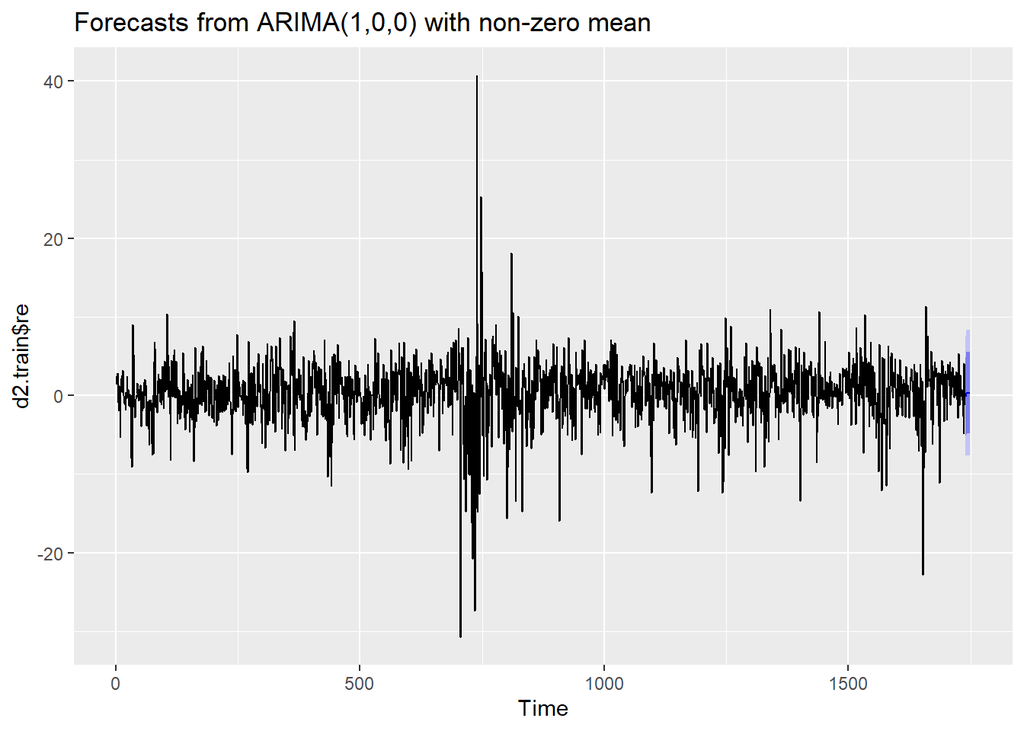

```r
ar1_expost = predict(ar1, n.ahead = 9)
autoplot(forecast(ar1))
```

```r
ar1_expost
```

```
## $pred
## Time Series:
## Start = 1740
## End = 1748
## Frequency = 1
## [1] -0.1117587  0.2209276  0.3153623  0.3421681  0.3497770  0.3519369  0.3525499
## [8]  0.3527240  0.3527734
##
## $se
## Time Series:
## Start = 1740
## End = 1748
## Frequency = 1
## [1] 3.903574 4.057791 4.069962 4.070941 4.071020 4.071026 4.071027 4.071027
## [9] 4.071027
```

Next, we estimate a VAR(1) model of equity returns, $re_t$, and dividend returns, $rd_t$, with the sample period ending December 2015, and generate ex post forecasts from January to September 2016. Combine the training data

```r
vardata <- cbind(d2.train$re, d2.train$rd)
colnames(vardata) <- c("re", "rd")
```

VAR(1) model of equity returns and dividend returns.

```r
var1 = vars::VAR(vardata, p = 1)
summary(var1)
```

```
##
## VAR Estimation Results:
## =========================
## Endogenous variables: re, rd
## Deterministic variables: const
## Sample size: 1738
## Log Likelihood: -7637.611
## Roots of the characteristic polynomial:
## 0.5325 0.2898
## Call:
## vars::VAR(y = vardata, p = 1)
##
##
## Estimation results for equation re:
## ===================================
## re = re.l1 + rd.l1 + const
##
##       Estimate Std. Error t value Pr(>|t|)
## re.l1  0.28652    0.02306  12.427   <2e-16 ***
## rd.l1  0.10451    0.06476   1.614   0.1067
## const  0.23793    0.09442   2.520   0.0118 *
## ---
## Signif. codes:  0 '***' 0.001 '**' 0.01 '*' 0.05 '.' 0.1 ' ' 1
##
##
## Residual standard error: 3.905 on 1735 degrees of freedom
## Multiple R-Squared: 0.08203, Adjusted R-squared: 0.08097
## F-statistic: 77.52 on 2 and 1735 DF,  p-value: < 2.2e-16
##
##
## Estimation results for equation rd:
## ===================================
## rd = re.l1 + rd.l1 + const
##
##        Estimate Std. Error t value Pr(>|t|)
## re.l1 -0.007703   0.007211  -1.068   0.2855
## rd.l1  0.535796   0.020254  26.454   <2e-16 ***
## const  0.062843   0.029530   2.128   0.0335 *
## ---
## Signif. codes:  0 '***' 0.001 '**' 0.01 '*' 0.05 '.' 0.1 ' ' 1
##
##
## Residual standard error: 1.221 on 1735 degrees of freedom
## Multiple R-Squared: 0.2898,  Adjusted R-squared: 0.289
## F-statistic:   354 on 2 and 1735 DF,  p-value: < 2.2e-16
##
##
##
## Covariance matrix of residuals:
##         re      rd
## re 15.2496 -0.4204
## rd -0.4204  1.4917
##
## Correlation matrix of residuals:
##          re       rd
## re  1.00000 -0.08815
## rd -0.08815  1.00000
```

We get the estimated VAR model
$$re_t = 0.2379+ 0.2865 re_{t-1} +0.1045 rd_{t-1}$$
,
$$rd_t = 0.0628 - 0.0077 re_{t-1} +0.5358 rd_{t-1}$$

Ex post forecasts from January to September 2016 using VAR(1) model.

```r
var1_expost <- predict(var1, n.ahead = 9)
var1_expost
```

```
## $re
##              fcst     lower    upper       CI
##  [1,] -0.02436857 -7.678174 7.629437 7.653806
##  [2,]  0.29509371 -7.664538 8.254725 7.959631
##  [3,]  0.36343742 -7.621710 8.348585 7.985147
##  [4,]  0.37033765 -7.617505 8.358181 7.987843
##  [5,]  0.36546492 -7.622832 8.353762 7.988297
##  [6,]  0.36039314 -7.628017 8.348804 7.988411
##  [7,]  0.35697449 -7.631469 8.345418 7.988443
##  [8,]  0.35494597 -7.633507 8.343399 7.988453
##  [9,]  0.35380545 -7.634650 8.342261 7.988455
##
## $rd
##            fcst     lower    upper       CI
##  [1,] 0.6137632 -1.780039 3.007565 2.393802
##  [2,] 0.3918824 -2.326966 3.110730 2.718848
##  [3,] 0.2705386 -2.534805 3.075882 2.805344
##  [4,] 0.2049965 -2.624586 3.034579 2.829582
##  [5,] 0.1698261 -2.666623 3.006275 2.836449
##  [6,] 0.1510194 -2.687378 2.989417 2.838398
##  [7,] 0.1409820 -2.697969 2.979933 2.838951
##  [8,] 0.1356303 -2.703478 2.974738 2.839108
##  [9,] 0.1327785 -2.706374 2.971931 2.839152
```

Now, we will compute the MSE and the RMSE for each in order to determine Which is the better forecasting model. MSE and RMSE of the AR(1) model for equity returns.

```r
d3.test <- subset(d1, d1$Date > 2015.12 & d1$Date <2016.10)
ar1_mse = mean((ar1_expost$pred - d3.test$re)^2)
ar1_mse
```

```
## [1] 10.34161
```

```r
ar1_rmse =sqrt(ar1_mse)
ar1_rmse
```

```
## [1] 3.215837
```

MSE and RMSE of the VAR(1) model for equity returns.

```r
var1_mse = mean((var1_expost$fcst$re-d3.test$re)^2)
var1_mse
```

```
## [1] 55.70562
```

```r
var1_rmse = sqrt(var1_mse)
var1_rmse
```

```
## [1] 7.46362
```

Next, we can estimate an AR(1) model of dividend returns $rd_t = \rho_0+\rho_1 rd_{t-1}+v_t$ and combine this model with the estimated model in the first equation to generate forecasts of equity returns from October to December 2016.

```r
d4 <- subset(d1, d1$Date <= 2016.09)
model = lm(re ~ rd, data = d4)
summary(model)
```

```
##
## Call:
## lm(formula = re ~ rd, data = d4)
##
## Residuals:
##     Min      1Q  Median      3Q     Max
## -30.932  -1.888   0.272   2.378  39.683
##
## Coefficients:
##             Estimate Std. Error t value Pr(>|t|)
## (Intercept)  0.37787    0.09749   3.876  0.00011 ***
## rd          -0.19121    0.06717  -2.847  0.00447 **
## ---
## Signif. codes:  0 '***' 0.001 '**' 0.01 '*' 0.05 '.' 0.1 ' ' 1
##
## Residual standard error: 4.061 on 1746 degrees of freedom
## Multiple R-squared:  0.00462,    Adjusted R-squared:  0.00405
## F-statistic: 8.104 on 1 and 1746 DF,  p-value: 0.00447
```

$\hat{re_t} = 0.3779 - 0.1912 \hat {rd_t} = 0.3779 - 0.1912 (\hat{\rho_0}+ \hat{\rho_1} rd_{t-1})$

AR(1)model $rd_t = \rho_0+\rho_1 rd_{t-1}+v_t$ using the time before Oct 2016 to predict Oct2016 to Dec2016.

```r
rd.fit =  arima(d4$rd, order = c(1,0,0))
summary(rd.fit)
```

```
##
## Call:
## arima(x = d4$rd, order = c(1, 0, 0))
##
## Coefficients:
##          ar1  intercept
##       0.5383     0.1242
## s.e.  0.0202     0.0631
##
## sigma^2 estimated as 1.486:  log likelihood = -2826.54,  aic = 5659.08
##
## Training set error measures:
##                        ME     RMSE       MAE MPE MAPE      MASE        ACF1
## Training set 0.0008502243 1.218934 0.7739507 NaN  Inf 0.9335134 -0.09308245
```

```r
rd_expost = predict(rd.fit, n.ahead = 3)
rd_expost
```

```
## $pred
## Time Series:
## Start = 1749
## End = 1751
## Frequency = 1
## [1] 0.1519711 0.1391310 0.1322193
##
## $se
## Time Series:
## Start = 1749
## End = 1751
## Frequency = 1
## [1] 1.218934 1.384314 1.428662
```

$\hat{re_t} = 0.3779 - 0.1912 \hat {rd_t}$, where $\hat{rd_t} = 0.1242 + 0.5383{rd_{t-1}}$. Plug the predicted dividend returns into the model, we get the forecast of equity returns from October to December 2016.

```r
d4.test = subset(d1, d1$Date <= 2016.12 & d1$Date >=2016.10)
rdpred = c(rd_expost$pred[[1]], rd_expost$pred[[2]], rd_expost$pred[[3]])
d4.test = d4.test[1:length(d4.test$P),] %>%
  mutate(rdpred = rdpred)
re_forecast = c(summary(model)$coefficients[1,'Estimate'] +
                  summary(model)$coefficients[2, 'Estimate']*d4.test$rdpred )
re_forecast
```

```
## [1] 0.3488099 0.3512651 0.3525867
```

Now, we will estimate an AR(2) model of dividend returns $rd_t = \rho_0+\rho_1 rd_{t-1}+\rho_2 rd_{t-2} +v_t,$ and combine this model in place of the AR(1) model just above to generate forecasts of equity returns from October to December 2016.

Estimate AR(2) model and use it to forecast dividend returns from October to December 2016.

```r
rd.fit2 =  arima(d4$rd, order = c(2,0,0))
summary(rd.fit2)
```

```
##
## Call:
## arima(x = d4$rd, order = c(2, 0, 0))
##
## Coefficients:
##          ar1     ar2  intercept
##       0.4463  0.1710      0.122
## s.e.  0.0236  0.0236      0.075
##
## sigma^2 estimated as 1.442:  log likelihood = -2800.63,  aic = 5609.26
##
## Training set error measures:
##                       ME    RMSE       MAE MPE MAPE      MASE        ACF1
## Training set 0.001805827 1.20098 0.7662248 NaN  Inf 0.9241948 -0.01080442
```

```r
rd_expost2 = predict(rd.fit2, n.ahead = 3)
rd_expost2
```

```
## $pred
## Time Series:
## Start = 1749
## End = 1751
## Frequency = 1
## [1] 0.1816693 0.1578231 0.1481794
##
## $se
## Time Series:
## Start = 1749
## End = 1751
## Frequency = 1
## [1] 1.200980 1.315179 1.388315
```

The estimated AR(2)model is $\hat{rd_t} = 0.122+ 0.4463 \hat{rd_{t-1}}+ 0.1710 \hat{rd_{t-2}}$.

Plugging the predicted dividend returns into the model, we get the forecast of equity returns from October to December 2016.

```r
d4.test2 = subset(d1, d1$Date <= 2016.12 & d1$Date >=2016.10)
rdpred2 = c(rd_expost2$pred[[1]], rd_expost2$pred[[2]], rd_expost2$pred[[3]])
d4.test2 = d4.test2[1:length(d4.test2$P),] %>%
  mutate(rdpred2 = rdpred2)
re_forecast2 = c(summary(model)$coefficients[1,'Estimate'] +
                 summary(model)$coefficients[2, 'Estimate']*d4.test2$rdpred2 )
re_forecast2
```

```
## [1] 0.3431312 0.3476909 0.3495350
```